# HOMEWORK 1

Fatma Zehra Cetin - IE582 - Fall 2018

**1. EXPLANATIONS AND COMMENTS OF PERFORMING TASKS**

**Task 1:**

**Task 1 a):**

**A. Explanation**

In order to understand if bookmakers are good at deciding over 2.5 odds, I draw a scatter plot of implied “over” probability average in a bin versus the fraction of games finished over for the corresponding bin. And also I draw the line (x=y). I chose 5 bookmaker respectively : Pinnacle, Unibet, 10Bet, Tipico and Betsson. In order to fraction of the games finished over is meaningful, according to the cases I merge bins in such cases.

**B. Comments of plots**

1. Pinnacle for initial odds:

For compute to meaningful statistic, I tried different probability intervals according to number of games in these bins and I determined cut point as 0.25. For a successful bookmaker these points should be on the line(x=y). Therefore when we consider the plot we can conclude that: Pinnacle is a successful bookmaker. Sure there are some outliers but they can be negligible. In general we can say that Pinnacle’s odds are trustable for over/under bet types for over odds.

2. Pinnacle for final odds:

For compute to meaningful statistic, I tried different probability intervals according to number of games in these bins and I determined cut point as 0.25. For a successful bookmaker these points should be on the line(x=y which means predicted probabilities and emprical probabilities almost same). Therefore when we consider the plot we can conclude that: Pinnacle is a successful bookmaker. Sure there are some outliers but they can be negligible. When we compare this plot with Pinnacle’s initial odds plot, we can also observe that prediction of odds became much more trustable. Because these points are more look like on the line. In general we can say that Pinnacle’s odds are trustable for over/under bet types for over odds.

3. Unibet for initial odds:

For compute to meaningful statistic, I tried different probability intervals according to number of games in these bins and I determined cut point as 0.25. For a successful bookmaker these points should be on the line(x=y). Therefore when we consider the plot we can conclude that: Unibet is a successful bookmaker according to this plot.

4. Unibet for final odds:

For compute to meaningful statistic, I tried different probability intervals according to number of games in these bins and I determined cut point as 0.25. For a successful bookmaker these points should be on the line(x=y which means predicted probabilities and emprical probabilities almost same). Therefore when we consider the plot we can conclude that: Unibet is a successful bookmaker. Sure there are some outliers but they can be negligible. When we compare this plot with Unibet’s initial odds plot, we can also observe prediction of odd became less trustable but still trustable because the line looks like more x=y. When we compare this plot with Unibet’s initial odds plot, we can see that number of outliers is rised. Because when we look the summary table we can see in (0.75,1] bin there are observations with emprical probability 0.5 and implied probability 0.76. In general we can say that Unibet’s odds are trustable for over/under bet types for over odds.

5. 10Bet for initial odds:

For compute to meaningful statistic, I tried different probability intervals according to number of games in these bins and I determined cut point as 0.25. For a successful bookmaker these points should be on the line(x=y). There is one outlier but it can be negligible. Because when we look the summary table we can see only one observation that emprical probabiility of over is 1 and implied probability is 0.78 in (0.75,1] bin in 2017. To sum up, when we consider the plot we can conclude that: 10Bet is a successful bookmaker according to this plot.

6. 10Bet for final odds:

7. Tipico for initial odds:

For compute to meaningful statistic, I tried different probability intervals according to number of games in these bins and I determined cut point as 0.25. For a successful bookmaker these points should be on the line(x=y). Therefore when we consider the plot we can conclude that: Tipico is a successful bookmaker. There is one outlier but it can be negligible. Because when we look the summary table we can see only one observation that emprical probabiility of over is 1 and implied probability is 0.78 in (0.75,1] bin in 2017. In general we can say that Tipico’s odds are trustable for over/under bet types for over odds.

8. Tipico for final odds:

For compute to meaningful statistic, I tried different probability intervals according to number of games in these bins and I determined cut point as 0.25. For a successful bookmaker these points should be on the line(x=y). Therefore when we consider the plot we can conclude that: Betsson is a successful bookmaker. There is one outlier but it can be negligible. Because when we look the summary table we can see only one observation that emprical probabiility of over is 1 and implied probability is 0.77 in (0.75,1] bin in 2017. In general we can say that Betsson’s odds are trustable for over/under bet types for over odds.

10. Betsson for final odds:

**Task 1 b):**

**A. Explanation**

In order to perform this task, I used ggplot2. It allowed me draw plot seperately for each bin with help of facet_wrap at once. Bins can be seen at top of the plot. For task 1 and b part, I chose Pinnacle as a bookmaker. For compute the meaningful statistic, I chose bin 0.25. Because below this cut point, there were bins with little observations (i.e. 3 games). In addition, I used final odds for evaluate the success of the bookmaker. Due to I couldn’t add the label the plot, I should explain what the colors represent:

Blue: Implied over probability

Red: Emprical over probability

**Task 2**

**A. Explanation**

I focused on the change of the odss for match results for 1x2 bet type in this task. Like in task 1 part b, I used ggplot2. But in this case I considered not only initial and final odds but also I checked effect of bins over given time period (years). Due to I do not understand much bet issue, I couldn’t find any other factors. But if we determine factor(s) and want to check these factors, we can add these parameters and check them. In my work, I chose Pinnace as a bookmaker. For compute the meaningful statistic, I chose cut points as 0.25. Because below this cut point, there were bins with little observations. I couldn’t add the label, I wrote explanations seperately here:

Color of lines with their names:

blue: average implied probability for Home(odd1)

red:fraction of games Home (odd1)

purple:average implied probability for Away(odd2)

pink:fraction of games Away (odd2)

black:average implied probability for Draw(oddX)

yellow:fraction of games Draw (oddX)

Bins and odd types:

Bins on top of the plot represent the odd1 bins, right-most bins represent odd2 bins and other one represent oddX bins. For 2 plots these location of bins and color of lines are same. First plot is created with initial odds and second plot is created with final odds.

**B.Comment**

When I compare these two plots, I concluded that ,in general, final odds are overlap better (emprical and average implied probabilities). For spesific bins for each odd types and/or for specific odd type and spesific bin we can analyze the odd change. For example for away odds changes (purple line represents implied away probability and pink line represents emprical away probability) in (0,0.25] bin for home odd type is just meaningful for (0,0.25] draw bin and (0.5,0.75] away bin.

**2. FIGURES**

**2.1. Task 1 a):**

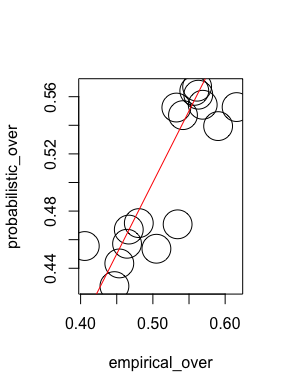

Pinnacle implied and emprical initial over probabilities

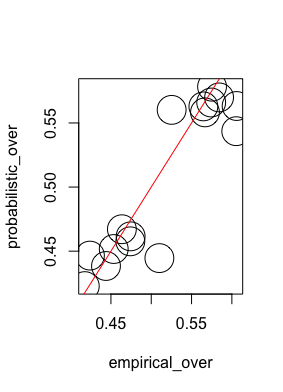

Pinnacle implied and emprical final over probabilities

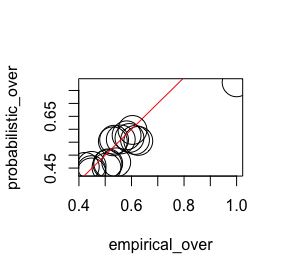

Unibet implied and emprical initial over probabilities

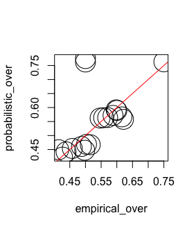

Unibet implied and emprical final over probabilities

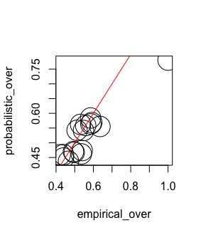

10Bet implied and emprical initial over probabilities

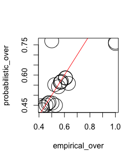

10Bet implied and emprical final over probabilities

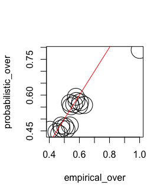

Tipico implied and emprical initial over probabilities

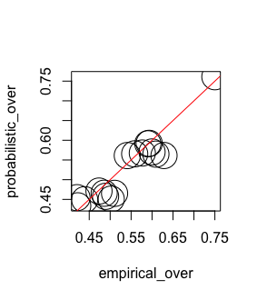

Tipico implied and emprical final over probabilities

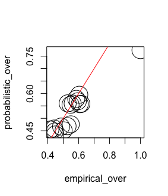

Betsson implied and emprical initial over probabilities

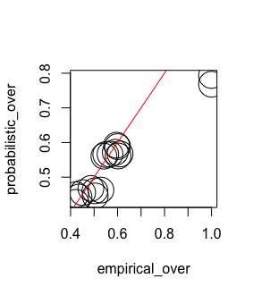

Betsson implied and emprical final over probabilities

**2.2. Task 1 b):**

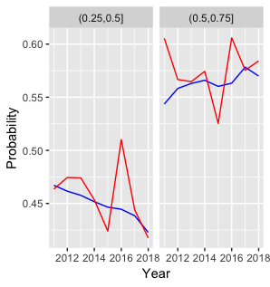

Pinnacle implied and emprical final over probabilites for each bin over years

**2.3. Task 2:**

I couldn’t add the label for which bin represent which odd type and for which line represent which the fraction of games or average implied probability of which type of odd, I wrote explanations seperately here:

Color of lines with their names:

blue: average implied probability for Home(odd1)

red:fraction of games Home (odd1)

purple:average implied probability for Away(odd2)

pink:fraction of games Away (odd2)

black:average implied probability for Draw(oddX)

yellow:fraction of games Draw (oddX)

Bins and odd types:

Above bins represent the odd1 bins, right-most bins represent odd2 bins and other one represent oddX bins.

For 2 plots these bins order and color of lines are same.

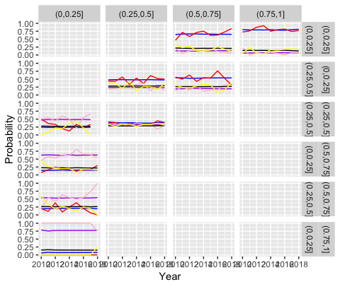

Pinnacle implied and emprical initial odd type(odd1, odd2, oddX) probabilities for 1X2 bet type for each bin over years

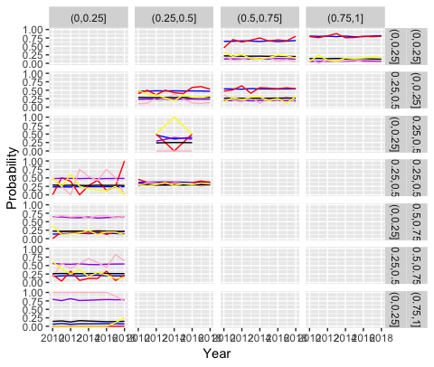

Pinnacle implied and emprical final odd type(odd1, odd2, oddX) probabilities for 1X2 bet type for each bin over years

**3. APPENDIX**

** Appendix: R codes for Plotting Figures**

**3.1. Task 1 a):**

**3.1.1. Code for Figure 1:**

require(data.table)

require(anytime)

matches=unique(matches)

matches[,match_date:=anydate(date)]

matches[,match_time:=anytime(date)]

matches=matches[order(home,-match_time)]

matches[,c(“match_date”,“date”):=NULL]

matches[,c(“HomeGoals”,“AwayGoals”):=tstrsplit(score,‘:’)]

matches[,Year:=year(match_time)]

matches[,Month:=month(match_time)]

matches[,Weekday:=wday(match_time)]

matches[,Hour:=hour(match_time)]

matches$HomeGoals=as.numeric(matches$HomeGoals)

matches[,AwayGoals:=as.numeric(AwayGoals)]

matches[,TotalGoals:=HomeGoals+AwayGoals]

matches[,IsOver:=0]

matches[TotalGoals>2,IsOver:=1]

matches[is.na(score)]

matches=matches[complete.cases(matches)]

odds_over_under=odd_details[betType==‘ou’ & totalhandicap==‘2.5’]

odds_over_under[,totalhandicap:=NULL]

odds_over_under=odds_over_under[order(matchId, oddtype,bookmaker,date)]

odds_over_under_initial=odds_over_under[,list(start_odd=odd[1]), by=list(matchId,oddtype,bookmaker)]

odds_over_under_final=odds_over_under[,list(final_odd=odd[.N]), by=list(matchId,oddtype,bookmaker)]

wide_odds_initial=dcast(odds_over_under_initial, matchId~oddtype+bookmaker, value.var=‘start_odd’)

wide_odds_final=dcast(odds_over_under_final, matchId~oddtype+bookmaker, value.var=‘final_odd’)

pinnacle_over_under=odds_over_under_initial[bookmaker==‘Pinnacle’]

pinnacle_wide=dcast(pinnacle_over_under, matchId~oddtype, value.var=‘start_odd’)

merged_matches=merge(matches,pinnacle_wide,by=‘matchId’)

merged_matches[,probOver:=1/over]

merged_matches[,probUnder:=1/under]

merged_matches[,totalProb:=probOver+probUnder]

merged_matches[,probOver:=probOver/totalProb]

merged_matches[,probUnder:=probUnder/totalProb]

merged_matches=merged_matches[complete.cases(merged_matches)]

merged_matches[,totalProb:=NULL]

cutpoints=seq(0,1,0.25)

merged_matches[,odd_cut_over:=cut(probOver,cutpoints)]

summary_table=merged_matches[,list(empirical_over=mean(IsOver), probabilistic_over=mean(probOver),.N), by=list(Year,odd_cut_over)]

summary_table=summary_table[order(Year)]

plot(summary_table[,list(empirical_over,probabilistic_over)],cex=4)

abline(0,1,col=‘red’)

**3.1.2.Code for final odds:**

I modified these parts only, other parts of code remained same. Changed parts:

pinnacle_over_under=odds_over_under_final[bookmaker==‘Pinnacle’]

pinnacle_wide=dcast(pinnacle_over_under, matchId~oddtype, value.var=‘final_odd’)

**3.1.3.For other bookmakers:**

I repeated steps in part a. I changed these parts:

tenbet_over_under=odds_ov_un_initial[bookmaker==‘10Bet’]

tenbet_wide=dcast(tenbet_over_under, matchId~oddtype, value.var=‘start_odd’)

merged_matches=merge(matches,tenbet_wide,by=‘matchId’)

**3.2. Task 1 b):**

**3.2.1. Code for Figure 1:**

Rest of the code is same as task 1 part A for bookmaker Pinnaclefor final odds. Only difference is last part(drawing plot).

ggplot(data=summary_table,aes((x = Year))) + geom_line(aes(y = probabilistic_over), color = “blue”) + geom_line( aes(y = empirical_over), color = “red” ) + facet_wrap(~ odd_cut_over) + xlab(‘Year’) +ylab(‘Probability’)

**3.3. Task 2:**

**3.3.1.Code for Figure 1 and 2:**

Rest of the code is same as task 1 part A, for initial part of code(arranging date etc.).

matches[,IsOdd1:=0]

matches[HomeGoals>AwayGoals,IsOdd1:=1]

matches[,IsOddX:=0]

matches[HomeGoals==AwayGoals,IsOddX:=1]

matches[,IsOdd2:=0]

matches[AwayGoals>HomeGoals,IsOdd2:=1]

odds_1x2=odd_details[betType==‘1x2’]

odds_1x2=odds_1x2[order(matchId, oddtype,bookmaker,date)]

odds_1x2_initial=odds_1x2[,list(start_odd=odd[1]), by=list(matchId,oddtype,bookmaker)]

odds_1x2_final=odds_1x2[,list(final_odd=odd[.N]), by=list(matchId,oddtype,bookmaker)]

wide_odds_initial=dcast(odds_1x2_initial, matchId~oddtype+bookmaker, value.var=‘start_odd’)

wide_odds_final=dcast(odds_1x2_final, matchId~oddtype+bookmaker, value.var=‘final_odd’)

pinnacle_1x2_initial=odds_1x2_initial[bookmaker==‘Pinnacle’]

pinnacle_wide_initial=dcast(pinnacle_1x2_initial, matchId~oddtype, value.var=‘start_odd’)

pinnacle_1x2_final=odds_1x2_final[bookmaker==‘Pinnacle’]

pinnacle_wide_final=dcast(pinnacle_1x2_final, matchId~oddtype, value.var=‘final_odd’)

merged_matches_initial=merge(matches,pinnacle_wide_initial,by=‘matchId’)

merged_matches_final=merge(matches,pinnacle_wide_final,by=‘matchId’)

merged_matches_initial[,probOdd1:=1/odd1]

merged_matches_initial[,probOdd2:=1/odd2]

merged_matches_initial[,probOddX:=1/oddX]

merged_matches_final[,probOdd1:=1/odd1]

merged_matches_final[,probOdd2:=1/odd2]

merged_matches_final[,probOddX:=1/oddX]

merged_matches_initial[,totalProb:=probOdd1+probOdd2+probOddX]

merged_matches_final[,totalProb:=probOdd1+probOdd2+probOddX]

merged_matches_initial[,probOdd1:=probOdd1/totalProb]

merged_matches_final[,probOdd1:=probOdd1/totalProb]

merged_matches_initial[,probOdd2:=probOdd2/totalProb]

merged_matches_final[,probOdd2:=probOdd2/totalProb]

merged_matches_initial[,probOddX:=probOddX/totalProb]

merged_matches_final[,probOddX:=probOddX/totalProb]

merged_matches_initial=merged_matches_initial[complete.cases(merged_matches_initial)]

merged_matches_initial[,totalProb:=NULL]

merged_matches_final=merged_matches_final[complete.cases(merged_matches_final)]

merged_matches_final[,totalProb:=NULL]

cutpoints=seq(0,1,0.25)

merged_matches_initial[,odd_cut_odd1:=cut(probOdd1,cutpoints)]

merged_matches_initial[,odd_cut_odd2:=cut(probOdd2,cutpoints)]

merged_matches_initial[,odd_cut_oddX:=cut(probOddX,cutpoints)]

merged_matches_final[,odd_cut_odd1:=cut(probOdd1,cutpoints)]

merged_matches_final[,odd_cut_odd2:=cut(probOdd2,cutpoints)]

merged_matches_final[,odd_cut_oddX:=cut(probOddX,cutpoints)]

summary_table_initial=merged_matches_initial[,list(empirical_odd1=mean(IsOdd1),probabilistic_odd1=mean(probOdd1),empirical_odd2=mean(IsOdd2),probabilistic_odd2=mean(probOdd2),empirical_oddX=mean(IsOddX),probabilistic_oddX=mean(probOddX),.N),by=list(Year,odd_cut_odd1,odd_cut_odd2,odd_cut_oddX)]

summary_table_final=merged_matches_final[,list(empirical_odd1=mean(IsOdd1),probabilistic_odd1=mean(probOdd1),empirical_odd2=mean(IsOdd2),probabilistic_odd2=mean(probOdd2),empirical_oddX=mean(IsOddX),probabilistic_oddX=mean(probOddX),.N),by=list(Year,odd_cut_odd1,odd_cut_odd2,odd_cut_oddX)]

summary_table_initial=summary_table_initial[order(Year)]

summary_table_final=summary_table_final[order(Year)]

ggplot(data=summary_table_initial,aes((x = Year))) + geom_line(aes(y = probabilistic_odd1), color = “blue”) + geom_line( aes(y = empirical_odd1), color = “red” ) + geom_line(aes(y = probabilistic_odd2), color = “purple”) + geom_line( aes(y = empirical_odd2), color = “pink” ) + geom_line(aes(y = probabilistic_oddX), color = “black”) + geom_line( aes(y = empirical_oddX), color = “yellow” ) + facet_grid(odd_cut_odd2 ~ odd_cut_oddX ~ odd_cut_odd1) + xlab(‘Year’) +ylab(‘Probability’)

ggplot(data=summary_table_final,aes((x = Year))) + geom_line(aes(y = probabilistic_odd1), color = “blue”) + geom_line( aes(y = empirical_odd1), color = “red” ) + geom_line(aes(y = probabilistic_odd2), color = “purple”) + geom_line( aes(y = empirical_odd2), color = “pink” ) + geom_line(aes(y = probabilistic_oddX), color = “black”) + geom_line( aes(y = empirical_oddX), color = “yellow” ) + facet_grid(odd_cut_odd2 ~ odd_cut_oddX ~ odd_cut_odd1) + xlab(‘Year’) +ylab(‘Probability’)